# DATA 607 Week 9 Assignment: Using Web APIs - New York Times

Matheesha Thambeliyagodage

April 9, 2017

The New York Times web site provides a rich set of APIs, as described here: http://developer.nytimes.com/docs . The goal of the Week 9 assignment is to use one of the New York Times APIs, construct an interface in R to read in the JSON data, and transform it to an R dataframe.

```r
library(ggplot2)
library(knitr)
library(tidyjson)
library(sqldf)
library(RCurl)
library(dplyr)
library(tidyr)
```

Construct the Request URI using the Books API.

```r
api_key <- "b72e3548831c4431a88db5b27ad33d87"
main_url <- "https://api.nytimes.com/svc/books/v3/lists/best-sellers/history.json"
request <- getURL(paste0(main_url,'?api-key=', api_key))
```

Below shows the structure of the Books API json response.It illustrate the json format.

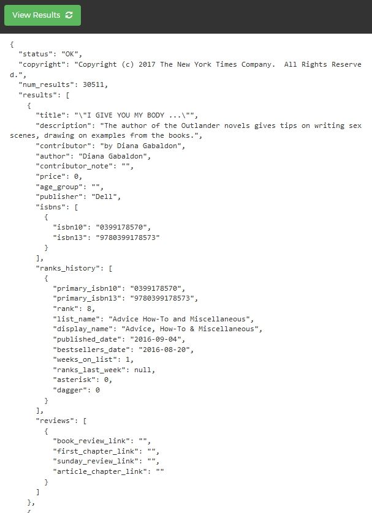

According to the above format ,using tidyjson I extracted key information from the JSON structure using the pipeline operator %>%. In this case, the JSON structure is complex. In this particular case, the “books_df” object was created, but when entered to “ranks_history” object it isterted to pull multiple rows because of different “published_date”, “primary_isbn13”, then I comented them .

```r
books_df <- request %>%
    spread_values(status = jstring("status"))  %>%
    enter_object("results") %>%             # Look at their cart
      gather_array("document.id") %>%
       spread_values(book_names = jstring("title"),
                description = jstring("description"),
                author = jstring("author"),
                price =jnumber("price"),
                publisher = jstring("publisher"))
        # enter_object("ranks_history") %>%
        # gather_array("document.id") %>%
        # spread_values(published_on = jstring("published_date"),
        #               rank = jnumber("rank"),
        #               ISBN = jstring("primary_isbn13"))
```

```r
kable(books_df)
```

| document.id | status | book_names | description | author | price | publisher |
| --- | --- | --- | --- | --- | --- | --- |
| 1 | OK | “I GIVE YOU MY BODY …” | The author of the Outlander novels gives tips on writing sex scenes, drawing on examples from the books. | Diana Gabaldon | 0.00 | Dell |
| 2 | OK | “MOST BLESSED OF THE PATRIARCHS” | A character study that attempts to make sense of Jeffersons contradictions. | Annette Gordon-Reed and Peter S Onuf | 0.00 | Liveright |
| 3 | OK | #ASKGARYVEE | The entrepreneur expands on subjects addressed on his Internet show, like marketing, management and social media. | Gary Vaynerchuk | 0.00 | HarperCollins |
| 4 | OK | #GIRLBOSS | An online fashion retailer traces her path to success. | Sophia Amoruso | 0.00 | Portfolio/Penguin/Putnam |
| 5 | OK | $100 STARTUP | How to build a profitable start up for $100 or less and be your own boss. | Chris Guillebeau | 23.00 | Crown Business |
| 6 | OK | $20 PER GALLON |  | Christopher Steiner | 0.00 | Grand Central |
| 7 | OK | ’57, Chicago | NA | Steve Monroe | 0.00 | NA |
| 8 | OK | ‘ROCK OF AGES:’‘ROLLING STONE’‘HISTORY OF ROCK AND ROLL’ | NA | GEOFFREY STOKES, KEN TUCKER’ ’ED WARD | 0.00 | NA |
| 9 | OK | ‘THE HIGH ROAD TO CHINA: GEORGE BOGLE, THE PANCHEN LAMA AND THE FIRST BRITISH EXPEDITION TO TIBET’ | NA | KATE TELTSCHER | 0.00 | NA |
| 10 | OK | ’TIL DEATH |  | Sharon Sala | 0.00 | Harlequin Mira |
| 11 | OK | ’TIL DEATH DO US PART | A matchmaker in Victorian England turns to a crime novelist for help when she starts receiving a series of disturbingly personalized trinkets. | Amanda Quick | 0.00 | Berkley |
| 12 | OK | ’Til Faith Do Us Part: How Interfaith Marriage is Transforming America | NA | Naomi Schaefer Riley | 0.00 | NA |
| 13 | OK | ’TIS THE SEASON | Two classic holiday stories  “Under the Christmas Tree” (2009) and “Midnight Confessions” (2010)  plus the novella “Backward Glance” (1991). | Ron Carr | 0.00 | Harlequin Mira |
| 14 | OK | …and the Horse He Rode In On: The People V. Kenneth Starr | NA | James Carville | 0.00 | NA |
| 15 | OK | .HACK G.U. , VOL. 5 | This series, set in the future, is about an online, multiplayer game run amok. This volume concludes the tale. | Hamazaki Tatsuya | 10.99 | TOKYOPOP |
| 16 | OK | 1 Ragged Ridge Road | NA | David Adams Richards | 0.00 | NA |
| 17 | OK | 1,000 PLACES TO SEE BEFORE YOU DIE | A guide for traveling the world; second edition updated with new entries. | Patricia Schultz | 0.00 | Workman |
| 18 | OK | 1,000 RECORDINGS TO HEAR BEFORE YOU DIE | Operas, rock albums, blues, classical music, world music and other essentials, from a musician and music journalist. | Tom Moon | 0.00 | Workman |
| 19 | OK | 1,227 QUITE INTERESTING FACTS TO BLOW YOUR SOCKS OFF | A compilation of interesting information on subjects ranging from Zeus to Zuckerberg. | John Lloyd and others | 0.00 | Norton |
| 20 | OK | 1,339 QUITE INTERESTING FACTS TO MAKE YOUR JAW DROP | Informative morsels of arcana and triva. | John Lloyd, John Mitchinson and James Harkin | 0.00 | Norton |

#### Creating an aggregated data frame from the above to find the publishers popularity. And plot them in a graph

```r
df1 <- sqldf("select publisher,count(*) Count from books_df group by publisher ")
```

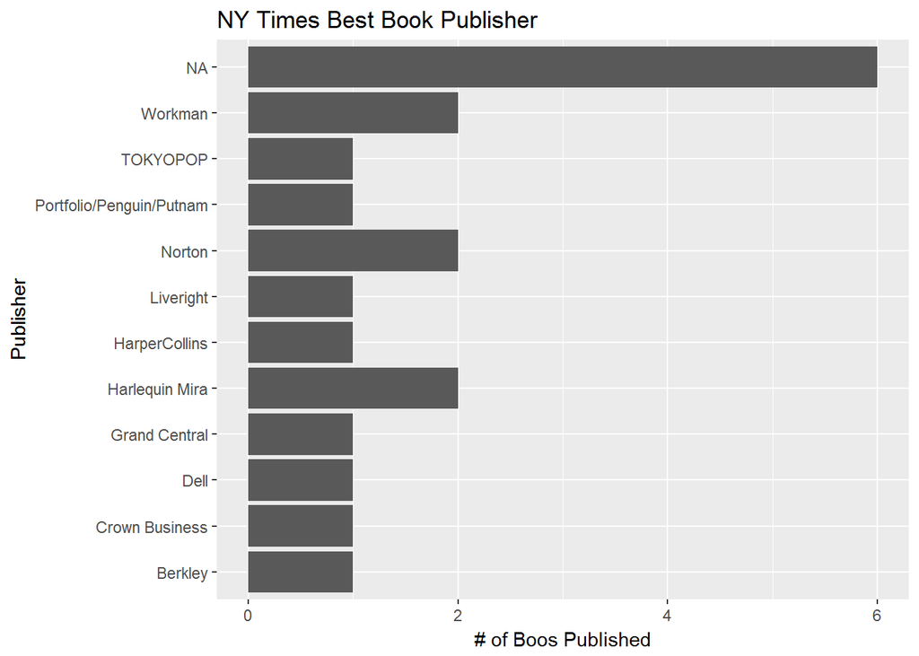

```r
 ggplot( data = df1, aes  (x = publisher, y=Count )) +
   geom_bar(stat="identity") +
   coord_flip() +
   scale_fill_manual(values=c("#ff0000", "#ffff00", "#00ff00")) +
   xlab("Publisher") +
   ylab("# of Boos Published") +
   ggtitle ("NY Times Best Book Publisher") +
   theme(legend.position="bottom") +
   guides(fill=guide_legend(title="Direction of Change Since Last Week:"))
```